# R Notebook Assignement_4

PRELIMINARY STEPS

```r
install.packages("pacman")
```

```
Error in install.packages : Updating loaded packages
```

```r
library(pacman)
p_load(tidyverse, psych, magrittr, readr, DHARMa, broom, stats, caret, vcd, fmsb, lmtest)
```

QUESTIONS 1 & 2 Load the training and test data files, cleaning them up as needed, in an R script. Select the variables you need, and store them in appropriate dataframes

–> see join R script as specify on the instruction (Open the file named “question_1.R”) Created tidy datafiles are names final_testdata.dat and final_traindata.dat

QUESTION 3. Explore the data with whatever summary statistics/graphs you think necessary. Interpret your findings. What do you expect to find in the modelling phase on the basis of what you see thus far?

```r
#load train and test datasets, use only the train dataset to interpret the following questions
#question 3,4 & 5 have been done with these datasets since questions 1&2 were answered after
load("eye_FR_traindata-1")
load("eye_FR_testdata-1")
```

```r
#remove all missing values from the dataset
traindata <- na.omit(traindata)
#First representation of our data to have a global idea
pairs.panels(traindata, stars = TRUE, main = "Figure 1.  Bivariate scatter plots, histograms and Pearson correlation between variables")
#some descriptive statistics, saved as a new dataset & visualisation of these
traindata_stats <- describe(traindata)
traindata_stats
```

|  | vars | n | mean | sd | median | trimmed | mad | min | max | range | skew | kurtosis | se |
| --- | --- | --- | --- | --- | --- | --- | --- | --- | --- | --- | --- | --- | --- |
| particip* | 1 | 114 | 59.04 | 33.88 | 59.5 | 59.04 | 43.00 | 1 | 117 | 116 | -0.02 | -1.22 | 3.17 |
| lineuptpta* | 2 | 114 | 1.50 | 0.50 | 1.5 | 1.50 | 0.74 | 1 | 2 | 1 | 0.00 | -2.02 | 0.05 |
| lineupacc | 3 | 114 | 0.53 | 0.50 | 1.0 | 0.53 | 0.00 | 0 | 1 | 1 | -0.10 | -2.01 | 0.05 |
| exposure* | 4 | 114 | 1.51 | 0.50 | 2.0 | 1.51 | 0.00 | 1 | 2 | 1 | -0.03 | -2.02 | 0.05 |
| confidence | 5 | 114 | 55.77 | 31.59 | 50.0 | 56.79 | 44.48 | 0 | 100 | 100 | -0.21 | -1.10 | 2.96 |
| lineuprt | 6 | 114 | 28113.64 | 22686.33 | 20646.0 | 23607.48 | 12094.31 | 5009 | 124143 | 119134 | 2.33 | 5.75 | 2124.77 |
| automatic | 7 | 114 | 2.19 | 1.36 | 2.0 | 2.02 | 1.48 | 1 | 5 | 4 | 0.77 | -0.80 | 0.13 |
| facecomparison | 8 | 114 | 2.96 | 1.41 | 3.0 | 2.96 | 1.48 | 1 | 5 | 4 | 0.16 | -1.33 | 0.13 |

```r
describeBy(traindata, group = traindata$lineupacc)
```

```
 Descriptive statistics by group
group: 0
```

|  | vars | n | mean | sd | median | trimmed | mad | min | max | range | skew | kurtosis | se |
| --- | --- | --- | --- | --- | --- | --- | --- | --- | --- | --- | --- | --- | --- |
| particip* | 1 | 54 | 56.57 | 35.88 | 55.5 | 56.18 | 50.41 | 2 | 115 | 113 | 0.09 | -1.45 | 4.88 |
| lineuptpta* | 2 | 54 | 1.63 | 0.49 | 2.0 | 1.66 | 0.00 | 1 | 2 | 1 | -0.52 | -1.76 | 0.07 |
| lineupacc | 3 | 54 | 0.00 | 0.00 | 0.0 | 0.00 | 0.00 | 0 | 0 | 0 | NaN | NaN | 0.00 |
| exposure* | 4 | 54 | 1.78 | 0.42 | 2.0 | 1.84 | 0.00 | 1 | 2 | 1 | -1.30 | -0.32 | 0.06 |
| confidence | 5 | 54 | 46.76 | 30.34 | 50.0 | 45.73 | 37.06 | 0 | 100 | 100 | 0.20 | -0.98 | 4.13 |
| lineuprt | 6 | 54 | 31580.13 | 26512.78 | 23220.0 | 26517.57 | 14610.28 | 5009 | 111186 | 106177 | 1.79 | 2.44 | 3607.93 |
| automatic | 7 | 54 | 2.15 | 1.29 | 2.0 | 2.00 | 1.48 | 1 | 5 | 4 | 0.75 | -0.77 | 0.18 |
| facecomparison | 8 | 54 | 2.76 | 1.24 | 3.0 | 2.70 | 1.48 | 1 | 5 | 4 | 0.39 | -0.86 | 0.17 |

```
-----------------------------------------------------------------------------
group: 1
```

|  | vars | n | mean | sd | median | trimmed | mad | min | max | range | skew | kurtosis | se |
| --- | --- | --- | --- | --- | --- | --- | --- | --- | --- | --- | --- | --- | --- |
| particip* | 1 | 60 | 61.25 | 32.12 | 61.5 | 61.58 | 32.62 | 1 | 117 | 116 | -0.09 | -0.99 | 4.15 |
| lineuptpta* | 2 | 60 | 1.38 | 0.49 | 1.0 | 1.35 | 0.00 | 1 | 2 | 1 | 0.47 | -1.81 | 0.06 |
| lineupacc | 3 | 60 | 1.00 | 0.00 | 1.0 | 1.00 | 0.00 | 1 | 1 | 0 | NaN | NaN | 0.00 |
| exposure* | 4 | 60 | 1.27 | 0.45 | 1.0 | 1.21 | 0.00 | 1 | 2 | 1 | 1.03 | -0.96 | 0.06 |
| confidence | 5 | 60 | 63.88 | 30.70 | 70.0 | 66.92 | 29.65 | 0 | 100 | 100 | -0.63 | -0.69 | 3.96 |
| lineuprt | 6 | 60 | 24993.80 | 18258.80 | 19905.0 | 21965.60 | 11423.43 | 6071 | 124143 | 118072 | 3.01 | 12.63 | 2357.20 |
| automatic | 7 | 60 | 2.23 | 1.42 | 2.0 | 2.04 | 1.48 | 1 | 5 | 4 | 0.75 | -0.93 | 0.18 |
| facecomparison | 8 | 60 | 3.15 | 1.53 | 3.0 | 3.19 | 1.48 | 1 | 5 | 4 | -0.08 | -1.57 | 0.20 |

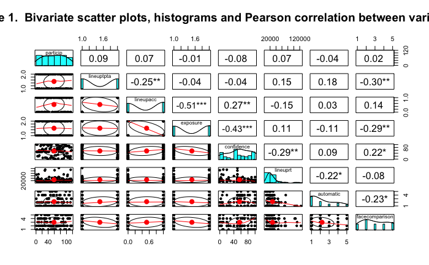

```r
#explore the distribution of numerical/scale variables (confidence, lineuprt, automatic and facecomparison)
attach(traindata)
par(mfrow = c(2,2))
```

```r
hist(confidence, main = "", xlab = "Confidence")
hist(automatic, main = "", xlab = "Automatic strategy")
```

```r
hist(facecomparison, main = "", xlab = "Face comparison strategy")
hist(lineuprt, main = "", xlab = "Decision latency")
```

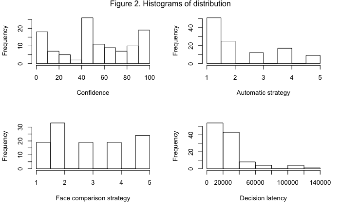

```r
mtext("Figure 2. Histograms of distribution", side=3, outer = TRUE, line=-1)
```

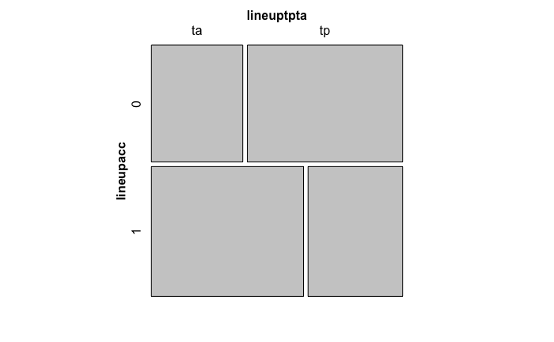

```r
#relation between lineup accuracy and presence/absence of the target in the lineup
mosaic(~ lineupacc + lineuptpta, data = traindata)
```

From this very first graph (figure 1), we can already some interesting patterns whoch should be further explored. In fact, accuracy seems to be related with exposure time and confidence, while both are also correlated to each other. Then, confidence is also correlated with decision latency, while and both variables do not follow a normal distribution. In fact, none or the continuous variable follow a normal distribution (figure 2), even if it could be the case once split by accuracy, but lets do that later if we need it. The presence or absence of the target in the lineup (lineuptpta) is negatively correlated with lineup accuracy, and should also be more explored, as well as the usage of a facecomparison strategy according to the presence or absence of the target. The face conparison strategy seems to be in relation with many of the other variable, namely the automatic strategy (surprisingly), confidence, exposure time and presence/absence of the target. This first analyse indicates three important points: simple effect are present, interaction should be considered (especially with presence/absence of the target and exposure time, since these variables are manipulated variables), and a logistic regression will be run since we would like to predict accuracy (binary/nominal variable) with nominal, categorical and numerical variables. Moreover, at this stage descriptive statistics are not very useful, except to have a global idea of overal results.

```
$title
[1] "Figure 3. Boxplot on distribution of confidence according to identification accuracy"

$x
[1] "Accuracy"

$y
[1] "Confidence"

attr(,"class")
[1] "labels"
```

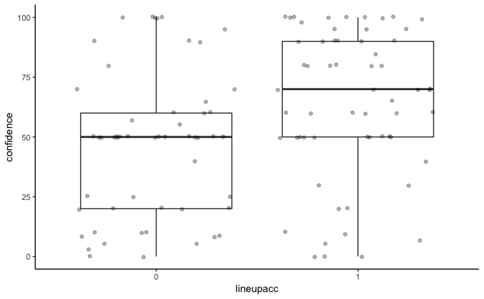

```r
#consider some graphs to explore more specifically the correlations saw in Figure 1.
traindata$lineupacc <- as.factor(traindata$lineupacc)
ggplot(traindata, aes(lineupacc, confidence))+
  geom_boxplot()+
  geom_jitter(alpha = .3)+
  theme_classic()+
install.packages("pacman")
  labs(title = "Figure 3. Boxplot on distribution of confidence according to identification accuracy", x = "Accuracy", y = "Confidence")
```

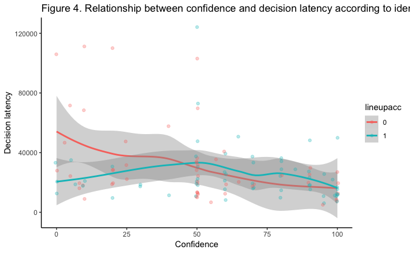

```r
ggplot(traindata, aes(confidence, lineuprt, group = lineupacc, color = lineupacc))+
  geom_smooth()+
  geom_jitter(alpha = .3)+
  theme_classic()+
  labs(title = "Figure 4. Relationship between confidence and decision latency according to identification accuracy", x = "Confidence", y = "Decision latency")
```

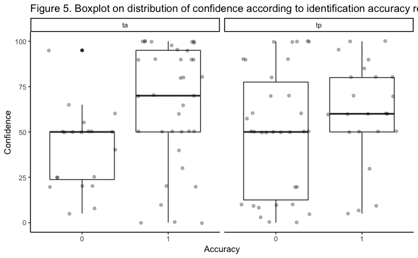

```r
ggplot(traindata, aes(lineupacc, confidence))+
  geom_boxplot()+
  geom_jitter(alpha = .3)+
  facet_wrap(~ lineuptpta)+
  theme_classic()+
  labs(title = "Figure 5. Boxplot on distribution of confidence according to identification accuracy regarding to presence of absence of the target in the lineup", x = "Accuracy", y = "Confidence")
```

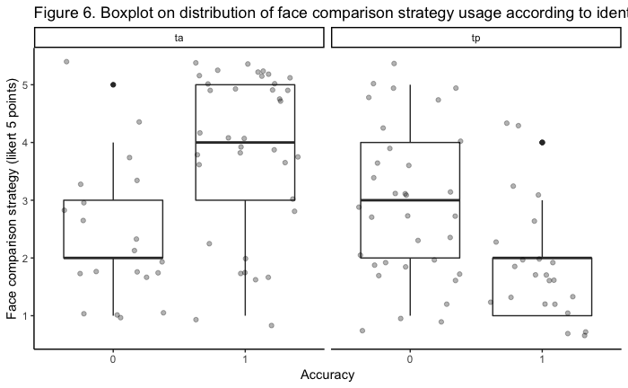

```r
ggplot(traindata, aes(lineupacc, facecomparison))+
  geom_boxplot()+
  geom_jitter(alpha = .3)+
  facet_wrap(~ lineuptpta)+
  theme_classic()+
  labs(title = "Figure 6. Boxplot on distribution of face comparison strategy usage according to identification accuracy regarding to presence of absence of the target in the lineup", x = "Accuracy", y = "Face comparison strategy (likert 5 points)")
```

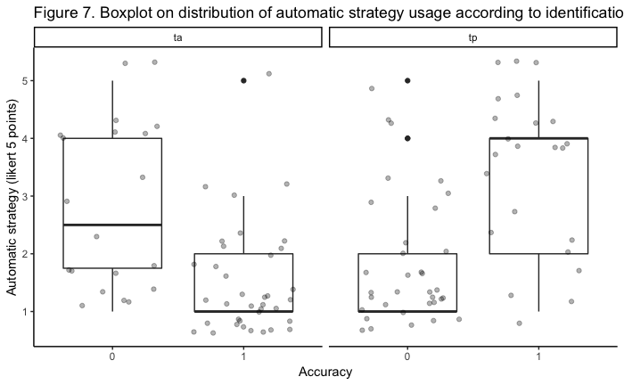

```r
ggplot(traindata, aes(lineupacc, automatic))+
  geom_boxplot()+
  geom_jitter(alpha = .3)+
  facet_wrap(~ lineuptpta)+
  theme_classic()+
  labs(title = "Figure 7. Boxplot on distribution of automatic strategy usage according to identification accuracy regarding to presence of absence of the target in the lineup", x = "Accuracy", y = "Automatic strategy (likert 5 points)")
```

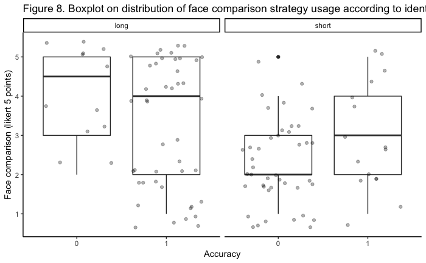

```r
ggplot(traindata, aes(lineupacc, facecomparison))+
  geom_boxplot()+
  geom_jitter(alpha = .3)+
  facet_wrap(~ exposure)+
  theme_classic()+
  labs(title = "Figure 8. Boxplot on distribution of face comparison strategy usage according to identification accuracy regarding to exposure duration to the event", x = "Accuracy", y = "Face comparison (likert 5 points)")
```

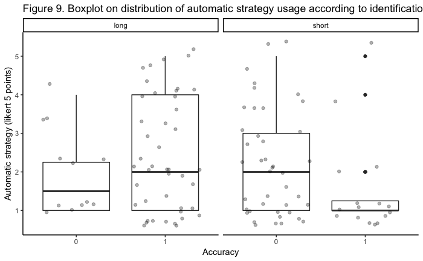

```r
ggplot(traindata, aes(lineupacc, automatic))+
  geom_boxplot()+
  geom_jitter(alpha = .3)+
  facet_wrap(~ exposure)+
  theme_classic()+
  labs(title = "Figure 9. Boxplot on distribution of automatic strategy usage according to identification accuracy regarding to exposure duration to the event", x = "Accuracy", y = "Automatic strategy (likert 5 points)")
```

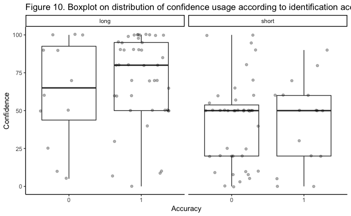

```r
ggplot(traindata, aes(lineupacc, confidence))+
  geom_boxplot()+
  geom_jitter(alpha = .3)+
  facet_wrap(~ exposure)+
  theme_classic()+
  labs(title = "Figure 10. Boxplot on distribution of confidence usage according to identification accuracy regarding to exposure duration to the event", x = "Accuracy", y = "Confidence")
```

Thus, we expect found more confidence after an accurate decision than an inaccurate one (Figure 3), and an interaction between confidence and decision time in the way that the more the participant is confident in his/her decision, the more the decision is quick, independantly of the accuracy of the decision, except when the participant is truly not confident: they take more time for inacurate decision than for accurate ones (Figure 4). Then, even if confidence and exposure duration are quite correlated, the difference seems to be concentrated in target-absent lineup: participant are more likely to be accurate than inaccurate when they report a high confidence in target absent lineup (figure 5). Then, about the strategies, we should find a effect of the presence/absence of the target in the usage of face comparison strategy, since it looks like participant who report using face comparison strategy (namely a higher score on the scale) are more lakely to be accurate than inaccurate in target-absent lineups but inaccurate than accurate in target-present lineups (Figure 6). For the automatic strategy, we found no correlation with accuracy, however if we add an interaction with presence and absence of the target, we observe a reverse pattern: participant who report using an automatic strategy are more likely to be inaccurate than accurate when the target in absent of the lineup, but more accurate than accurate when the target is present in the lineup. Then, it seems to have less face comparison strategy overall after a short than a long exposure duration (Figure 8), but more accurate decision when the participant report an automatic strategy usage after a long exposure duration than after a short exposure duration (Figure 9). Finally, confidence is higher after a long than a short exposure duration, regardless to accuracy.

We should then consider adding interaction with design variables (presence/absence of the target in the lineup and exposure duration) in the regression model.

QUESTION 4. Build a logistic regression model that uses some or all of the variables above. You should use the logic of training and test sets, building the model on the training set, and then testing it on the test set.

```r
#Build a first model, exploring only the design variables (target presence/absence and exposure duration)
traindata$lineuptpta <- as.factor(traindata$lineuptpta)
model1 <- glm(lineupacc ~ lineuptpta + exposure, family = "binomial", data = traindata)
summary(model1)
```

```
Call:
glm(formula = lineupacc ~ lineuptpta + exposure, family = "binomial",
    data = traindata)

Deviance Residuals:
    Min       1Q   Median       3Q      Max
-2.1896  -1.0359   0.4368   0.8934   2.0333

Coefficients:
              Estimate Std. Error z value Pr(>|z|)
(Intercept)     2.3017     0.5093   4.519 6.20e-06 ***
lineuptptatp   -1.5894     0.5111  -3.110  0.00187 **
exposureshort  -2.6441     0.5133  -5.151 2.58e-07 ***
---
Signif. codes:  0 '***' 0.001 '**' 0.01 '*' 0.05 '.' 0.1 ' ' 1

(Dispersion parameter for binomial family taken to be 1)

    Null deviance: 157.72  on 113  degrees of freedom
Residual deviance: 115.19  on 111  degrees of freedom
AIC: 121.19

Number of Fisher Scoring iterations: 4
```

```r
NagelkerkeR2(model1)
```

```
$N
[1] 114

$R2
[1] 0.4155432
```

```r
#test the classification success of the model
testmodel1 <- predict(model1, traindata, type = "response")
table(round(testmodel1 + 0.05), traindata$lineupacc)
```

```
     0  1
  0 42 16
  1 12 44
```

```r
confusionMatrix(as.factor(round(testmodel1 + 0.05)), as.factor(traindata$lineupacc))
```

```
Confusion Matrix and Statistics

          Reference
Prediction  0  1
         0 42 16
         1 12 44

               Accuracy : 0.7544
                 95% CI : (0.6649, 0.8302)
    No Information Rate : 0.5263
    P-Value [Acc > NIR] : 4.617e-07

                  Kappa : 0.5092
 Mcnemar's Test P-Value : 0.5708

            Sensitivity : 0.7778
            Specificity : 0.7333
         Pos Pred Value : 0.7241
         Neg Pred Value : 0.7857
             Prevalence : 0.4737
         Detection Rate : 0.3684
   Detection Prevalence : 0.5088
      Balanced Accuracy : 0.7556

       'Positive' Class : 0
```

With this very first model, we observe a significant effect of the presence/absence of the target in the lineup on accuracy, as well as the exposure duration. In fact, this simple model actually has a 75% classification accuracy (78% sensitivity and 73% specificity). However, since lineuptpta and exposure are only out design variables, we then comput a new model, with additionnal variable: our base model. The effect size, measured by the Nagelkerke R2 = .42.

```r
#base model, with main effect only
model2 <- glm(lineupacc ~ lineuptpta + exposure + confidence + lineuprt + automatic + facecomparison, family = "binomial", data = traindata)
summary(model2)
```

```
Call:
glm(formula = lineupacc ~ lineuptpta + exposure + confidence +
    lineuprt + automatic + facecomparison, family = "binomial",
    data = traindata)

Deviance Residuals:
    Min       1Q   Median       3Q      Max
-2.3401  -0.8570   0.3938   0.7660   2.2214

Coefficients:
                 Estimate Std. Error z value Pr(>|z|)
(Intercept)     3.180e+00  1.301e+00   2.444  0.01454 *
lineuptptatp   -1.714e+00  5.409e-01  -3.169  0.00153 **
exposureshort  -2.747e+00  5.906e-01  -4.651  3.3e-06 ***
confidence      4.345e-03  8.389e-03   0.518  0.60451
lineuprt       -8.037e-06  1.240e-05  -0.648  0.51677
automatic      -5.046e-02  1.845e-01  -0.274  0.78447
facecomparison -2.339e-01  1.896e-01  -1.234  0.21737
---
Signif. codes:  0 '***' 0.001 '**' 0.01 '*' 0.05 '.' 0.1 ' ' 1

(Dispersion parameter for binomial family taken to be 1)

    Null deviance: 157.72  on 113  degrees of freedom
Residual deviance: 112.92  on 107  degrees of freedom
AIC: 126.92

Number of Fisher Scoring iterations: 4
```

```r
NagelkerkeR2(model2)
```

```
$N
[1] 114

$R2
[1] 0.4336983
```

```r
#test the classification success of the model
testmodel2 <- predict(model2, traindata, type = "response")
table(round(testmodel2 + 0.05), traindata$lineupacc)
```

```
     0  1
  0 34 13
  1 20 47
```

```r
confusionMatrix(as.factor(round(testmodel2 + 0.05)), as.factor(traindata$lineupacc))
```

```
Confusion Matrix and Statistics

          Reference
Prediction  0  1
         0 34 13
         1 20 47

               Accuracy : 0.7105
                 95% CI : (0.6181, 0.7916)
    No Information Rate : 0.5263
    P-Value [Acc > NIR] : 4.598e-05

                  Kappa : 0.4157
 Mcnemar's Test P-Value : 0.2963

            Sensitivity : 0.6296
            Specificity : 0.7833
         Pos Pred Value : 0.7234
         Neg Pred Value : 0.7015
             Prevalence : 0.4737
         Detection Rate : 0.2982
   Detection Prevalence : 0.4123
      Balanced Accuracy : 0.7065

       'Positive' Class : 0
```

In this model, we observe no additional significant direct effects of any other variable on the accuracy than the one already observed (of lineuptpta and exposure). However, the model is less accurate, with 71% of accurate classification (62% sensitivity and 78% specificity). Nagelkerke R2 is then = 43. Thus this, model fits less our data and is less accurate, the consistency is lower.

According to the our very first observations, we should consider adding interaction between our variables and design variables, since we observes some interesting correlations:

```r
#build a third model considering interactions
model3 <- glm(lineupacc ~ lineuptpta*automatic + lineuptpta*facecomparison + exposure*automatic + exposure*facecomparison + confidence*lineuptpta + confidence*exposure + lineuprt*lineuptpta + lineuprt*exposure, family = "binomial", data = traindata)
summary(model3)
```

```
Call:
glm(formula = lineupacc ~ lineuptpta * automatic + lineuptpta *
    facecomparison + exposure * automatic + exposure * facecomparison +
    confidence * lineuptpta + confidence * exposure + lineuprt *
    lineuptpta + lineuprt * exposure, family = "binomial", data = traindata)

Deviance Residuals:
     Min        1Q    Median        3Q       Max
-1.55058  -0.37053   0.02704   0.25778   2.97157

Coefficients:
                               Estimate Std. Error z value Pr(>|z|)
(Intercept)                   2.179e+00  2.256e+00   0.966 0.334082
lineuptptatp                 -1.840e-01  2.715e+00  -0.068 0.945958
automatic                    -1.832e+00  8.501e-01  -2.155 0.031166 *
facecomparison                2.939e-01  4.996e-01   0.588 0.556415
exposureshort                -3.837e+00  2.799e+00  -1.371 0.170373
confidence                    7.130e-02  3.694e-02   1.930 0.053624 .
lineuprt                     -1.910e-05  3.282e-05  -0.582 0.560575
lineuptptatp:automatic        3.191e+00  8.831e-01   3.613 0.000303 ***
lineuptptatp:facecomparison  -1.834e+00  6.327e-01  -2.898 0.003750 **
automatic:exposureshort      -7.722e-01  7.002e-01  -1.103 0.270139
facecomparison:exposureshort  1.098e+00  6.287e-01   1.746 0.080754 .
lineuptptatp:confidence      -6.544e-02  3.922e-02  -1.669 0.095168 .
exposureshort:confidence     -9.483e-03  2.697e-02  -0.352 0.725137
lineuptptatp:lineuprt         3.235e-06  4.532e-05   0.071 0.943101
exposureshort:lineuprt        3.537e-06  4.240e-05   0.083 0.933527
---
Signif. codes:  0 '***' 0.001 '**' 0.01 '*' 0.05 '.' 0.1 ' ' 1

(Dispersion parameter for binomial family taken to be 1)

    Null deviance: 157.722  on 113  degrees of freedom
Residual deviance:  56.668  on  99  degrees of freedom
AIC: 86.668

Number of Fisher Scoring iterations: 7
```

```r
NagelkerkeR2(model3)
```

```
$N
[1] 114

$R2
[1] 0.7845647
```

```r
#test the classification success of the model
testmodel3 <- predict(model3, traindata, type = "response")
table(round(testmodel3 + 0.05), traindata$lineupacc)
```

```
     0  1
  0 47  6
  1  7 54
```

```r
confusionMatrix(as.factor(round(testmodel3 + 0.05)), as.factor(traindata$lineupacc))
```

```
Confusion Matrix and Statistics

          Reference
Prediction  0  1
         0 47  6
         1  7 54

               Accuracy : 0.886
                 95% CI : (0.8129, 0.9379)
    No Information Rate : 0.5263
    P-Value [Acc > NIR] : <2e-16

                  Kappa : 0.7711
 Mcnemar's Test P-Value : 1

            Sensitivity : 0.8704
            Specificity : 0.9000
         Pos Pred Value : 0.8868
         Neg Pred Value : 0.8852
             Prevalence : 0.4737
         Detection Rate : 0.4123
   Detection Prevalence : 0.4649
      Balanced Accuracy : 0.8852

       'Positive' Class : 0
```

However, we consider a very last model, removing decision latency (lineuprt) which seems have no effect in out models, to see if the model is improved, as well as some interactions like confidence*exposure since our exploratory analysis show no interesting relationship (and previous models neither):

```r
#last model testing
model4 <- glm(lineupacc ~ lineuptpta*automatic + lineuptpta*facecomparison + exposure*automatic + exposure*facecomparison + confidence*lineuptpta , family = "binomial", data = traindata)
summary(model4)
```

```
Call:
glm(formula = lineupacc ~ lineuptpta * automatic + lineuptpta *
    facecomparison + exposure * automatic + exposure * facecomparison +
    confidence * lineuptpta, family = "binomial", data = traindata)

Deviance Residuals:
     Min        1Q    Median        3Q       Max
-1.48993  -0.36683   0.03626   0.23112   2.98260

Coefficients:
                             Estimate Std. Error z value Pr(>|z|)
(Intercept)                   1.55952    1.76695   0.883 0.377449
lineuptptatp                 -0.27160    2.09122  -0.130 0.896665
automatic                    -1.62748    0.75809  -2.147 0.031809 *
facecomparison                0.35429    0.49505   0.716 0.474198
exposureshort                -3.75564    2.11588  -1.775 0.075902 .
confidence                    0.05972    0.03028   1.972 0.048598 *
lineuptptatp:automatic        3.14092    0.83477   3.763 0.000168 ***
lineuptptatp:facecomparison  -1.93510    0.62013  -3.120 0.001806 **
automatic:exposureshort      -0.90845    0.69585  -1.306 0.191718
facecomparison:exposureshort  1.06161    0.62890   1.688 0.091404 .
lineuptptatp:confidence      -0.05419    0.03477  -1.558 0.119130
---
Signif. codes:  0 '***' 0.001 '**' 0.01 '*' 0.05 '.' 0.1 ' ' 1

(Dispersion parameter for binomial family taken to be 1)

    Null deviance: 157.722  on 113  degrees of freedom
Residual deviance:  57.349  on 103  degrees of freedom
AIC: 79.349

Number of Fisher Scoring iterations: 7
```

```r
NagelkerkeR2(model4)
```

```
$N
[1] 114

$R2
[1] 0.7812695
```

```r
#test the classification success of the model
testmodel4 <- predict(model1, traindata, type = "response")
table(round(testmodel4 + 0.05), traindata$lineupacc)
```

```
     0  1
  0 42 16
  1 12 44
```

```r
confusionMatrix(as.factor(round(testmodel4 + 0.05)), as.factor(traindata$lineupacc))
```

```
Confusion Matrix and Statistics

          Reference
Prediction  0  1
         0 42 16
         1 12 44

               Accuracy : 0.7544
                 95% CI : (0.6649, 0.8302)
    No Information Rate : 0.5263
    P-Value [Acc > NIR] : 4.617e-07

                  Kappa : 0.5092
 Mcnemar's Test P-Value : 0.5708

            Sensitivity : 0.7778
            Specificity : 0.7333
         Pos Pred Value : 0.7241
         Neg Pred Value : 0.7857
             Prevalence : 0.4737
         Detection Rate : 0.3684
   Detection Prevalence : 0.5088
      Balanced Accuracy : 0.7556

       'Positive' Class : 0
```

Finally, we can conclude with this analysis, that the more robust model is the third one (model3), which present interesting main effect and interactions with a hight rate (89%) of accuract classification. We now can test its model on the test dataset, to explore in which extent it can be applicable/replicable:

```r
#build the best model (model3) on the test dataset
model5 <- glm(lineupacc ~ lineuptpta*automatic + lineuptpta*facecomparison + exposure*automatic + exposure*facecomparison + confidence*lineuptpta + confidence*exposure + lineuprt*lineuptpta + lineuprt*exposure, family = "binomial", data = testdata)
summary(model5)
```

```
Call:
glm(formula = lineupacc ~ lineuptpta * automatic + lineuptpta *
    facecomparison + exposure * automatic + exposure * facecomparison +
    confidence * lineuptpta + confidence * exposure + lineuprt *
    lineuptpta + lineuprt * exposure, family = "binomial", data = testdata)

Deviance Residuals:
    Min       1Q   Median       3Q      Max
-2.4428  -0.4851   0.1198   0.4857   3.1122

Coefficients:
                               Estimate Std. Error z value Pr(>|z|)
(Intercept)                   2.155e+00  2.800e+00   0.770 0.441423
lineuptptaTP                  2.737e-01  3.042e+00   0.090 0.928303
automatic                    -1.056e+00  5.138e-01  -2.055 0.039908 *
facecomparison                7.919e-01  5.022e-01   1.577 0.114829
exposureshort                -5.888e+00  3.144e+00  -1.873 0.061060 .
confidence                    9.129e-03  2.260e-02   0.404 0.686224
lineuprt                     -3.705e-05  3.001e-05  -1.234 0.217021
lineuptptaTP:automatic        1.850e+00  5.596e-01   3.305 0.000948 ***
lineuptptaTP:facecomparison  -1.628e+00  5.685e-01  -2.864 0.004187 **
automatic:exposureshort      -1.340e-01  5.917e-01  -0.226 0.820831
facecomparison:exposureshort  8.037e-02  5.641e-01   0.142 0.886694
lineuptptaTP:confidence      -1.524e-02  2.644e-02  -0.576 0.564359
exposureshort:confidence      4.462e-02  2.659e-02   1.678 0.093276 .
lineuptptaTP:lineuprt         1.815e-06  2.675e-05   0.068 0.945902
exposureshort:lineuprt        5.346e-05  3.021e-05   1.769 0.076828 .
---
Signif. codes:  0 '***' 0.001 '**' 0.01 '*' 0.05 '.' 0.1 ' ' 1

(Dispersion parameter for binomial family taken to be 1)

    Null deviance: 137.989  on 99  degrees of freedom
Residual deviance:  71.156  on 85  degrees of freedom
  (2 observations deleted due to missingness)
AIC: 101.16

Number of Fisher Scoring iterations: 6
```

```r
NagelkerkeR2(model5)
```

```
$N
[1] 100

$R2
[1] 0.6513075
```

```r
#test the classification success of the model
testmodel5 <- predict(model5, testdata, type = "response")
table(round(testmodel5 + 0.05), testdata$lineupacc)
```

```
     0  1
  0 40  4
  1  6 50
```

```r
confusionMatrix(as.factor(round(testmodel5 + 0.05)), as.factor(testdata$lineupacc))
```

```
Confusion Matrix and Statistics

          Reference
Prediction  0  1
         0 40  4
         1  6 50

               Accuracy : 0.9
                 95% CI : (0.8238, 0.951)
    No Information Rate : 0.54
    P-Value [Acc > NIR] : 6.923e-15

                  Kappa : 0.7981
 Mcnemar's Test P-Value : 0.7518

            Sensitivity : 0.8696
            Specificity : 0.9259
         Pos Pred Value : 0.9091
         Neg Pred Value : 0.8929
             Prevalence : 0.4600
         Detection Rate : 0.4000
   Detection Prevalence : 0.4400
      Balanced Accuracy : 0.8977

       'Positive' Class : 0
```

Once apply to the test model, the results are quite similar, even some difference appears in the signficativity of the factors. However, the classification accuracy still being very string (90%, with 87% sensitivity and 93% specificity).

We can also compute mode statistics in order to compare our models, as:

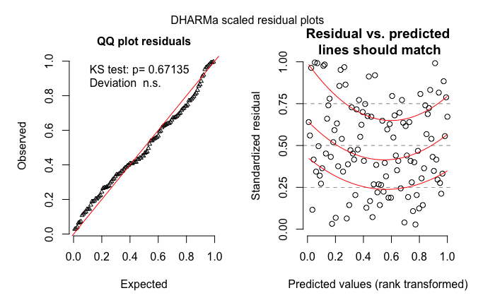

```r
#compute some plots to represent the best train model and the test model
plot(simulateResiduals(model3))
```

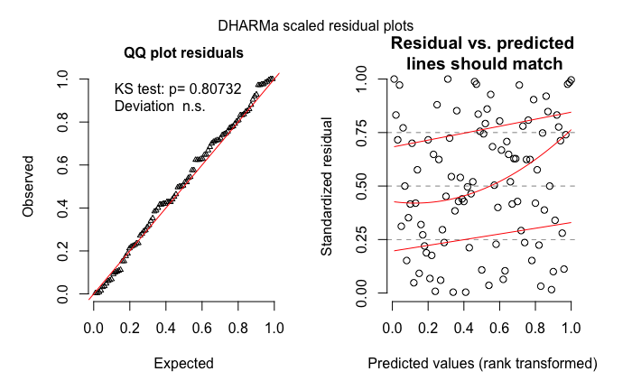

```r
plot(simulateResiduals(model5))
```

```r
#summary of R2, even if their usage is discutable - they still be comparable
r2_model1 <- NagelkerkeR2(model1)
r2_model2 <- NagelkerkeR2(model2)
r2_model3 <- NagelkerkeR2(model3)
r2_model4 <- NagelkerkeR2(model4)
#generate a table for R2
matrix(c(r2_model1,r2_model2,r2_model3,r2_model4), nrow = 4, ncol = 2, byrow = TRUE) -> matrix1
colnames(matrix1) <- c("N", "R2")
rownames(matrix1) <- c("Model 1", "Model 2", "Model 3", "Model 4")
matrix1
```

```
        N   R2
Model 1 114 0.4155432
Model 2 114 0.4336983
Model 3 114 0.7845647
Model 4 114 0.7812695
```

QUESTION 5. For a logistic regression model relating confidenceresp (= confidence) and lineuptpta to lineup accuracy, compute the following (i) the probability that someone who is > 80% confident is accurate; (ii) the odds that this person is correct; (iii) the partial odds ratio in the relation between lineuptpta and accuracy of decision. Assess the accuracy of the model using a confusion matrix. Check the amount of difference in the prediction errors (sensitivity and specificity – hint, use the confusionMatrix function from package caret).

```r
#build a new model with lineuptpta and confidence over accuracy
model6 <- glm(lineupacc ~ lineuptpta + confidence, family = "binomial", data = traindata)
summary(model6) #We can observe a significant effect of the two variables on accuracy
```

```
Call:
glm(formula = lineupacc ~ lineuptpta + confidence, family = "binomial",
    data = traindata)

Deviance Residuals:
    Min       1Q   Median       3Q      Max
-1.7920  -1.1070   0.6417   1.0268   1.7839

Coefficients:
              Estimate Std. Error z value Pr(>|z|)
(Intercept)  -0.409498   0.451868  -0.906  0.36481
lineuptptatp -1.048236   0.404820  -2.589  0.00961 **
confidence    0.018852   0.006694   2.816  0.00486 **
---
Signif. codes:  0 '***' 0.001 '**' 0.01 '*' 0.05 '.' 0.1 ' ' 1

(Dispersion parameter for binomial family taken to be 1)

    Null deviance: 157.72  on 113  degrees of freedom
Residual deviance: 142.13  on 111  degrees of freedom
AIC: 148.13

Number of Fisher Scoring iterations: 4
```

```r
NagelkerkeR2(model6)
```

```
$N
[1] 114

$R2
[1] 0.1705897
```

```r
#select only participants with confidence > or = to 80%, assign it to a new dataset
traindata$confidence <- as.numeric(traindata$confidence)
traindata2 <-
  traindata %>%
  filter(confidence >= 80)
#construct a new model containing this new filtered dataset
model7 <- glm(lineupacc ~ lineuptpta + confidence, family = "binomial", data = traindata2)
print(model7)
```

```
Call:  glm(formula = lineupacc ~ lineuptpta + confidence, family = "binomial",
    data = traindata2)

Coefficients:
 (Intercept)  lineuptptatp    confidence
    11.24320      -3.28944      -0.08802

Degrees of Freedom: 35 Total (i.e. Null);  33 Residual
Null Deviance:      42.54
Residual Deviance: 29.15    AIC: 35.15
```

```r
#get the probability
mean(predict(model7, data.frame(lineupacc = 1), type = "response"))
```

```
'newdata' had 1 row but variables found have 114 rows
```

```
[1] 0.8991102
```

```r
#get odds ratio
x <- predict(model7, data.frame(lineupacc = 1), type = "response")
```

```
'newdata' had 1 row but variables found have 114 rows
```

```r
odds <- mean(x/(1-x))
print(odds)
```

```
[1] 4264.112
```

```r
#for the confusionMatrix
for_matrix <- predict(model7, traindata, type = "response")
table(round(for_matrix, 0),traindata$lineupacc)
```

```
     0  1
  0  5  3
  1 49 57
```

```r
confusionMatrix(factor(as.numeric(for_matrix >= .5)),
                as.factor(traindata$lineupacc))
```

```
Confusion Matrix and Statistics

          Reference
Prediction  0  1
         0  5  3
         1 49 57

               Accuracy : 0.5439
                 95% CI : (0.4479, 0.6374)
    No Information Rate : 0.5263
    P-Value [Acc > NIR] : 0.3899

                  Kappa : 0.0445
 Mcnemar's Test P-Value : 4.365e-10

            Sensitivity : 0.09259
            Specificity : 0.95000
         Pos Pred Value : 0.62500
         Neg Pred Value : 0.53774
             Prevalence : 0.47368
         Detection Rate : 0.04386
   Detection Prevalence : 0.07018
      Balanced Accuracy : 0.52130

       'Positive' Class : 0
```

QUESTION 6. Show algebraically that the logit function used for logistic regression can be written in two alternate ways, representing probability, and odds, respectively - that is, that A, B, and C below are equivalent. Use the equation editor in Word to write your answer, or do it by hand, scan it, and upload it.

$$1 - \hat{p}_{1} = \frac{1}{e(\beta_{1}X_{1}+\beta_{2})}$$
GiTHub bonus: Link to my repository –> https://github.com/TaniaWittwer/Assignement_4.git